# La briscola nei bar italiani

## Accenni storici

Il gioco ha origini non troppo chiare:

- Alcune teorie indicano un’origine francese dai giochi brusquembille e bazzica, olandese (popolare tra i marinai) o addirittura spagnola (importata come brisca nel XVI secolo durante la dominazione).
- Il termine potrebbe derivare dal francese brisque, che indicava i galloni sulle uniformi dei soldati, o dalla Bazzica, un gioco simile.
- Arrivata in Italia probabilmente nel corso del ’700-800, la prima traccia scritta risale al 1828
- Importata via mare da marinai olandesi o attraverso la dominazione spagnola, l gioco si è radicato profondamente nella cultura italiana, specialmente in Toscana, Liguria, Campania e Sicilia, fino a diventare un rito di socializzazione in osterie e bar.
- Il primo trattato ufficiale di regole è del 1888

## Regole di base

- 40 carte
- 2 o 4 giocatori
- 3 carte a testa
- una carta capovolta sul tavolo, che decide il seme dominante: la briscola
- vince la mano chi tira la carta più alta dello stesso seme della prima carta tirata o la briscola più alta
- vince la partita che ha ottenuto il punteggio più alto (ogni carte ha un valore numerico)

## Consigli tattici

```r
LETTERS[c(13,1,9)]

LETTERS[c(6,9,4,1,18,19,9)]

LETTERS[c(4,5,9)]

LETTERS[c(14,15,14,14,9)]
```

[output not shown]

[output not shown]

## Consigli tattici

```r
LETTERS[c(13,1,9)]
```

```
[1] "M" "A" "I"
```

```r
LETTERS[c(6,9,4,1,18,19,9)]
```

```
[1] "F" "I" "D" "A" "R" "S" "I"
```

```r
LETTERS[c(4,5,9)]
```

```
[1] "D" "E" "I"
```

```r
LETTERS[c(14,15,14,14,9)]
```

```
[1] "N" "O" "N" "N" "I"
```

## Importanza culturale

Nel corso del tempo è diventato uno degli emblemi dell’italianità

## Importanza culturale

Nel corso del tempo è diventato uno degli emblemi dell’italianità

Rappresenta un moemento di socialita e un motivo di incontro

## Importanza culturale

Nel corso del tempo è diventato uno degli emblemi dell’italianità

Inoltre, è un punto di contatto fra generazioni

Rappresenta un moemento di socialita e un motivo di incontro

## Importanza culturale

Nel corso del tempo è diventato uno degli emblemi dell’italianità

Inoltre, è un punto di contatto fra generazioni

Rappresenta un moemento di socialita e un motivo di incontro

Ma non è da prendere sottogamba, “competizione” è la parola d’ordine

COMPETIZIONE

COMPETIZIONE

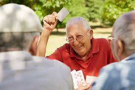

MA ANCHE DIVERTIMENTO

COMPETIZIONE

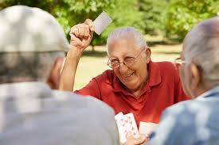

MA ANCHE DIVERTIMENTO

È proprio una cosa seria

## Concludendo

la brscola non è solo un gioco…

…ma un fatto di cultura

Se volete imparare ecco le

[regole](https://digilander.libero.it/elioab/data/RegolamentoBriscola.pdf)

GRAZIE DELL’ASCOLTO

GRAZIE DELL’ASCOLTO

SPERO DI AVERVI FATTO VENIRE VOGLIA DI GIOCARE ;)

Vera Gelli